# Understanding Activity Patterns from Behavioral Data

Monika Bagociute

September 18, 2026

## 1. Research overview

This project explores longitudinal physical-activity data from an Apple Health export to identify recurring behavioral patterns across days and times.

The analysis treats activity records as behavioral data and demonstrates a quantitative workflow for moving from raw, longitudinal data to interpretable behavioral insights.

### Research question

What behavioral patterns can be identified in longitudinal activity data, and how could these patterns inform opportunities for more personalized user experiences?

### Sub-questions

1. How does physical activity vary across days of the week?
2. At what times of day does activity tend to occur?
3. How consistent is activity over time, and are there recurring periods of lower activity?

### Research approach

The analysis uses exploratory quantitative methods to examine:

- longitudinal activity patterns
- weekday and weekend differences
- time-of-day patterns
- daily variability
- trends in activity over time

The final section translates observed behavioral patterns into hypotheses that could be explored through future quantitative or qualitative user research.

### Data

The data come from a personal Apple Health export. The raw health data are not included in this repository because they contain sensitive personal information. The analysis is structured so that the raw export can be supplied locally without being committed to GitHub.

### Tools

- R
- R Markdown
- tidyverse
- XML
- lubridate
- ggthemes

## 2. Data preparation

The Apple Health export is provided locally as a ZIP file containing an `export.xml` file. Because the data contain sensitive personal information, the raw export is excluded from version control.

The code below expects the export to be available locally and extracts the XML file for analysis.

```r
# Load required packages
library(XML)
library(tidyverse)
library(lubridate)
library(ggthemes)

# ---------------------------------------------------------
# 1. Set project directory
# ---------------------------------------------------------

project_dir <- getwd()

# If the R Markdown document is being knitted from the
# Analysis folder, move one level up to the project root.
if (basename(project_dir) == "Analysis") {
  project_dir <- dirname(project_dir)
}

# ---------------------------------------------------------
# 2. Define local data paths
# ---------------------------------------------------------

zip_path <- file.path(
  project_dir,
  "Data",
  "raw",
  "export.zip"
)

extraction_path <- file.path(
  project_dir,
  "Data",
  "raw",
  "apple_health_export"
)

# Check that the ZIP file exists
if (!file.exists(zip_path)) {
  stop(
    "Apple Health export not found at: ",
    zip_path
  )
}

# ---------------------------------------------------------
# 3. Extract the Apple Health export
# ---------------------------------------------------------

if (!dir.exists(extraction_path)) {
  dir.create(extraction_path, recursive = TRUE)
}

unzip(
  zip_path,
  exdir = extraction_path,
  overwrite = TRUE
)

# ---------------------------------------------------------
# 4. Locate export.xml
# ---------------------------------------------------------

xml_files <- list.files(
  extraction_path,
  pattern = "^export\\.xml$",
  recursive = TRUE,
  full.names = TRUE
)

if (length(xml_files) == 0) {
  stop("export.xml could not be found in the extracted Apple Health export.")
}

xml_path <- xml_files[1]

# ---------------------------------------------------------
# 5. Parse XML
# ---------------------------------------------------------

xml <- xmlParse(xml_path)

# Extract Record nodes into a data frame
df_record <- XML:::xmlAttrsToDataFrame(xml["//Record"])

# Inspect the raw data
glimpse(df_record)
```

```
## Rows: 303,481
## Columns: 9
## $ type          <chr> "HKQuantityTypeIdentifierHeight", "HKQuantityTypeIdentif…
## $ sourceName    <chr> "Health", "Health", "Monika’s iPhone", "Monika’s iPhone"…
## $ sourceVersion <chr> "14.4", "14.4", "14.4", "14.4", "14.4", "14.4", "14.4", …
## $ unit          <chr> "cm", "kg", "count", "count", "count", "count", "count",…
## $ creationDate  <chr> "2021-02-14 00:32:22 +0100", "2021-02-14 00:32:22 +0100"…
## $ startDate     <chr> "2021-02-14 00:32:22 +0100", "2021-02-14 00:32:22 +0100"…
## $ endDate       <chr> "2021-02-14 00:32:22 +0100", "2021-02-14 00:32:22 +0100"…
## $ value         <chr> "164", "64", "5", "45", "16", "14", "34", "67", "34", "1…
## $ device        <chr> NA, NA, "<<HKDevice: 0x300bd6c60>, name:iPhone, manufact…
```

## 3. Data cleaning and transformation

```r
# Clean and transform Apple Health records
df <- df_record %>%
  mutate(
    device = gsub(".*(name:)|,.*", "", device),
    value = as.numeric(as.character(value)),
    endDate = ymd_hms(endDate, tz = "Europe/Amsterdam"),
    startDate = ymd_hms(startDate, tz = "Europe/Amsterdam"),
    date = as.Date(endDate),
    year = year(endDate),
    month = month(endDate),
    day = day(endDate),
    yday = yday(endDate),
    wday = wday(endDate),
    hour = hour(endDate),
    minute = minute(endDate),
    type = str_remove(type, "HKQuantityTypeIdentifier")
  )

# Inspect available health measures
health_types <- df %>%
  distinct(type) %>%
  arrange(type)

health_types
```

```
##                                                   type
## 1                                   ActiveEnergyBurned
## 2                               AppleWalkingSteadiness
## 3                                    BasalEnergyBurned
## 4                                             BodyMass
## 5                               DistanceWalkingRunning
## 6                                       FlightsClimbed
## 7              HKCategoryTypeIdentifierAbdominalCramps
## 8                   HKCategoryTypeIdentifierBreastPain
## 9  HKCategoryTypeIdentifierHeadphoneAudioExposureEvent
## 10               HKCategoryTypeIdentifierLowerBackPain
## 11               HKCategoryTypeIdentifierMenstrualFlow
## 12                  HKCategoryTypeIdentifierPelvicPain
## 13               HKCategoryTypeIdentifierSleepAnalysis
## 14                              HeadphoneAudioExposure
## 15                                              Height
## 16                                           StepCount
## 17                          WalkingAsymmetryPercentage
## 18                      WalkingDoubleSupportPercentage
## 19                                        WalkingSpeed
## 20                                   WalkingStepLength
```

## 4. Daily activity patterns

```r
# Select step-count records
step_data <- df %>%
  filter(type == "StepCount") %>%
  filter(!is.na(value))

# Calculate total steps per day
daily_steps <- step_data %>%
  group_by(date) %>%
  summarise(
    total_steps = sum(value, na.rm = TRUE),
    .groups = "drop"
  ) %>%
  mutate(
    weekday = factor(
      weekdays(date),
      levels = c(
        "Monday", "Tuesday", "Wednesday",
        "Thursday", "Friday", "Saturday", "Sunday"
      )
    ),
    weekend = if_else(
      weekday %in% c("Saturday", "Sunday"),
      "Weekend",
      "Weekday"
    )
  ) %>%
  arrange(date)

# Inspect the resulting daily dataset
glimpse(daily_steps)
```

```
## Rows: 1,380
## Columns: 4
## $ date        <date> 2021-02-10, 2021-02-12, 2021-02-13, 2021-02-14, 2021-02-1…
## $ total_steps <dbl> 246, 169, 8067, 1879, 7255, 17478, 4505, 6347, 2345, 902, …
## $ weekday     <fct> Wednesday, Friday, Saturday, Sunday, Monday, Tuesday, Wedn…
## $ weekend     <chr> "Weekday", "Weekday", "Weekend", "Weekend", "Weekday", "We…
```

```r
# Basic descriptive statistics
daily_steps %>%
  summarise(
    n_days = n(),
    mean_steps = mean(total_steps, na.rm = TRUE),
    median_steps = median(total_steps, na.rm = TRUE),
    sd_steps = sd(total_steps, na.rm = TRUE),
    min_steps = min(total_steps, na.rm = TRUE),
    max_steps = max(total_steps, na.rm = TRUE)
  )
```

```
## # A tibble: 1 × 6
##   n_days mean_steps median_steps sd_steps min_steps max_steps
##    <int>      <dbl>        <dbl>    <dbl>     <dbl>     <dbl>
## 1   1380      7089.         6206    4767.         9     34526
```

## 5. Activity over time

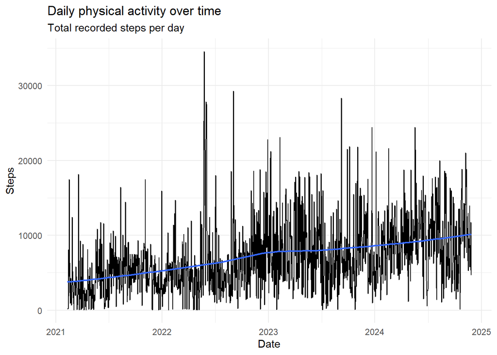

```r
ggplot(daily_steps, aes(x = date, y = total_steps)) +
  geom_line() +
  geom_smooth(
    method = "loess",
    se = FALSE,
    linewidth = 0.8
  ) +
  labs(
    title = "Daily physical activity over time",
    subtitle = "Total recorded steps per day",
    x = "Date",
    y = "Steps"
  ) +
  theme_minimal()
```

## 6. Weekday and weekend patterns

```r
# Summarise activity by weekday/weekend
weekday_summary <- daily_steps %>%
  group_by(weekend) %>%
  summarise(
    n_days = n(),
    mean_steps = mean(total_steps, na.rm = TRUE),
    median_steps = median(total_steps, na.rm = TRUE),
    sd_steps = sd(total_steps, na.rm = TRUE),
    .groups = "drop"
  )

weekday_summary
```

```
## # A tibble: 2 × 5
##   weekend n_days mean_steps median_steps sd_steps
##   <chr>    <int>      <dbl>        <dbl>    <dbl>
## 1 Weekday    987      7273.         6483    4547.
## 2 Weekend    393      6628.         4941    5258.
```

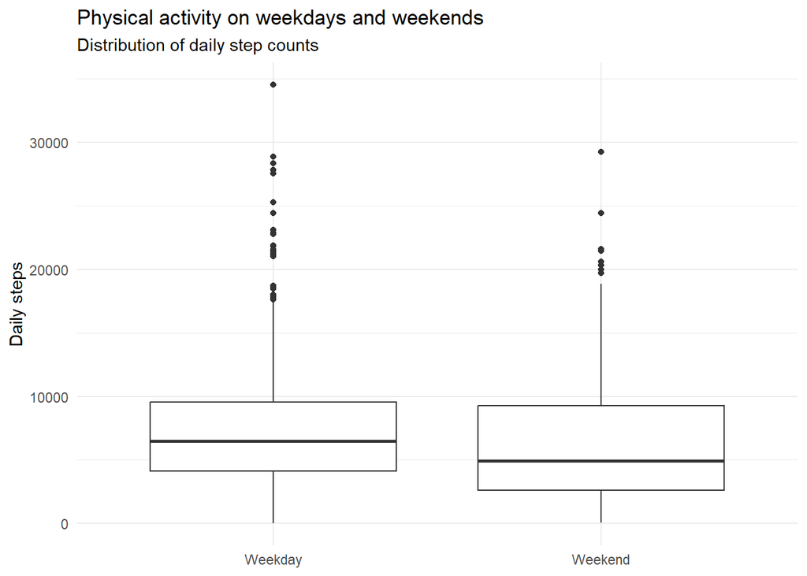

```r
ggplot(
  daily_steps,
  aes(x = weekend, y = total_steps)
) +
  geom_boxplot() +
  labs(
    title = "Physical activity on weekdays and weekends",
    subtitle = "Distribution of daily step counts",
    x = NULL,
    y = "Daily steps"
  ) +
  theme_minimal()
```

## 7. Time-of-day activity patterns

```r
# Summarise recorded steps by hour of day
hourly_steps <- step_data %>%
  group_by(hour) %>%
  summarise(
    total_steps = sum(value, na.rm = TRUE),
    mean_steps = mean(value, na.rm = TRUE),
    n_records = n(),
    .groups = "drop"
  )

hourly_steps
```

```
## # A tibble: 24 × 4
##     hour total_steps mean_steps n_records
##    <int>       <dbl>      <dbl>     <int>
##  1     0      170291       256.       666
##  2     1       71591       211.       340
##  3     2       47659       268.       178
##  4     3       36999       336.       110
##  5     4       29828       324.        92
##  6     5       12778       232.        55
##  7     6       46467       231.       201
##  8     7      161374       253.       638
##  9     8      303716       288.      1056
## 10     9      378891       280.      1355
## # ℹ 14 more rows
```

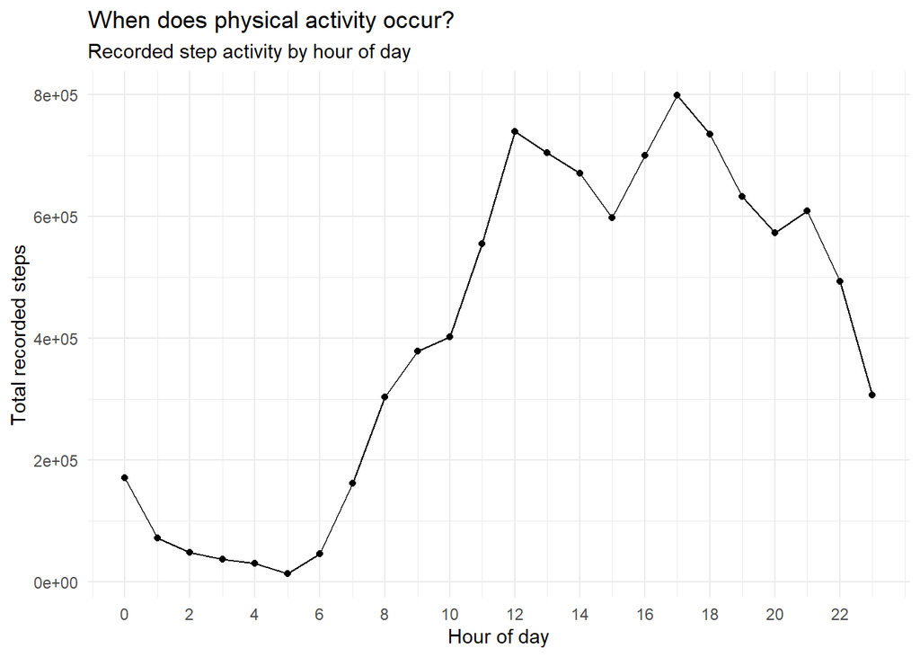

```r
ggplot(
  hourly_steps,
  aes(x = hour, y = total_steps)
) +
  geom_line() +
  geom_point() +
  scale_x_continuous(
    breaks = seq(0, 23, by = 2)
  ) +
  labs(
    title = "When does physical activity occur?",
    subtitle = "Recorded step activity by hour of day",
    x = "Hour of day",
    y = "Total recorded steps"
  ) +
  theme_minimal()
```